# Practical Machine learning

Joachim Allouche

7 apr 2019

## Practical Machine Learning Final Project

This project aim to predict how people did a certain exercise, using data fromuse data from accelerometers on the belt, forearm, arm, and dumbell of 6 participants. The data was collected by Velloso, E.; Bulling, A.; Gellersen, H.; Ugulino, W.; Fuks, H. Qualitative Activity Recognition of Weight Lifting Exercises. Proceedings of 4th International Conference in Cooperation with SIGCHI (Augmented Human ’13) . Stuttgart, Germany: ACM SIGCHI, 2013.

The paper contains a descibtion off how the data was prepared picking the relevant variables and splitting it in to a training ad testing set. After that there will be describtion and evaluation off Cross Validation and the two methods I have tried, Classification Tree and Random Forest. Finally I conclude that Random Forest is the best method for predickting how people did the exercise. To make the text readable some of the code has been hidden, at the end of the paper you will find all the code.

### Loading and preparing the data

The data is loaded from the same folder as my script.

```r
trainingdata <- read.csv("pml-training.csv", header = TRUE)
testdata <- read.csv("pml-testing.csv",header = TRUE)
```

##### Picking Features (Removing Variables)

```r
trainingdata <- trainingdata[,colSums(is.na(trainingdata))=="0"]
testdata <- testdata[,colSums(is.na(testdata))=="0"]
```

After that i am checking for variables with non to littel variability The variables that have non to little variability are then removed.

```r
nzv <- nearZeroVar(trainingdata)
trainingdata <- trainingdata[,-nzv]
nzv <- nearZeroVar(testdata)
testdata <- testdata[,-nzv]
```

Finally the first 6 variables are removed as they do not have any impact on the outcome. This leave us with a trainingset containing 19622 observations and 53 variables.

```r
trainingdata <- trainingdata[,-c(1:6)]
testdata <- testdata[,-c(1:6)]

dim(trainingdata)
```

```
## [1] 19622    53
```

#### slicing the data

In order to test different model without risking overfitting, the trainingset is split in to a smaller training set and a test set.

```r
set.seed(534)
intrain <- createDataPartition(trainingdata$classe, p = 0.7, list = FALSE)
traindata <- trainingdata[intrain,]
validdata <- trainingdata[-intrain,]
```

### Cross Validation Classification Tree and Random forest

To predict the outcome I am using to different methods first I am preparing my Cross Validation code which I will be using in order to limit the effect of overfitting. The function that i am using is the trainControl function with 5 folds by the end i am using ConfusionMatix to make the results clearer.

```r
crva <- trainControl(method = "cv", number=5)
```

#### Classification Tree

My first method is classification tree the result clearly an accuracy off .482 clearly indicates that this method is not productive.

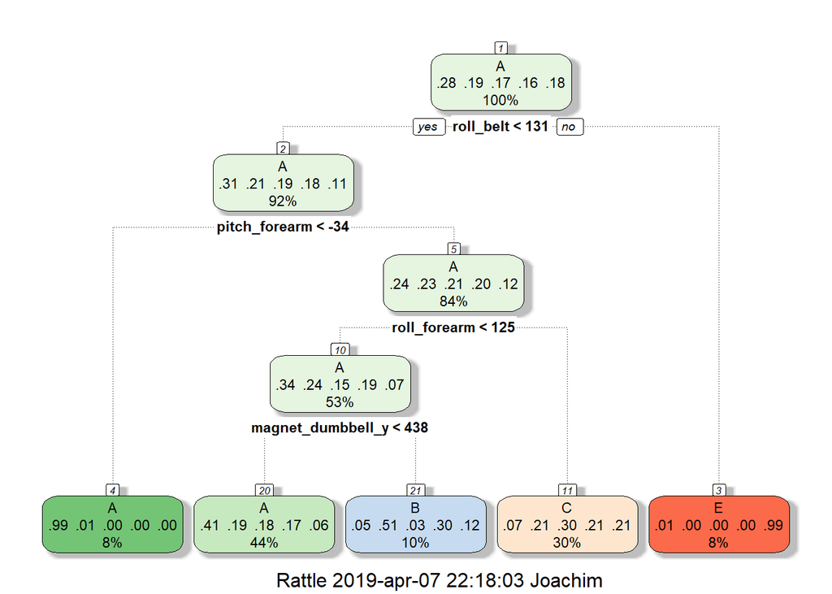

```r
model1 <- train(classe~.,data = traindata, method="rpart", trControl=crva)
fancyRpartPlot(model1$finalModel)
```

```r
p1 <- predict(model1, newdata = validdata)
confm1 <- confusionMatrix(validdata$classe,p1)
confm1$overall[1]
```

```
##  Accuracy
## 0.4820731
```

#### Random Forest Model

```r
model2 <- randomForest(classe~.,data = traindata, method="rf", trControl=crva, verbose=FALSE)
p2 <- predict(model2, newdata = validdata)
```

```r
confm2 <- confusionMatrix(validdata$classe,p2)
confm2
```

```
## Confusion Matrix and Statistics
##
##           Reference
## Prediction    A    B    C    D    E
##          A 1672    1    0    0    1
##          B    5 1134    0    0    0
##          C    0   11 1015    0    0
##          D    0    0    9  955    0
##          E    0    0    0    4 1078
##
## Overall Statistics
##
##                Accuracy : 0.9947
##                  95% CI : (0.9925, 0.9964)
##     No Information Rate : 0.285
##     P-Value [Acc > NIR] : < 2.2e-16
##
##                   Kappa : 0.9933
##  Mcnemar's Test P-Value : NA
##
## Statistics by Class:
##
##                      Class: A Class: B Class: C Class: D Class: E
## Sensitivity            0.9970   0.9895   0.9912   0.9958   0.9991
## Specificity            0.9995   0.9989   0.9977   0.9982   0.9992
## Pos Pred Value         0.9988   0.9956   0.9893   0.9907   0.9963
## Neg Pred Value         0.9988   0.9975   0.9981   0.9992   0.9998
## Prevalence             0.2850   0.1947   0.1740   0.1630   0.1833
## Detection Rate         0.2841   0.1927   0.1725   0.1623   0.1832
## Detection Prevalence   0.2845   0.1935   0.1743   0.1638   0.1839
## Balanced Accuracy      0.9983   0.9942   0.9945   0.9970   0.9991
```

The test clearly indicate that Random Forest is the best fitt, therefore the model with Random Forest will be used in the prediction Quiz.

```r
 predict(model2,newdata = testdata)
```

```
##  1  2  3  4  5  6  7  8  9 10 11 12 13 14 15 16 17 18 19 20
##  B  A  B  A  A  E  D  B  A  A  B  C  B  A  E  E  A  B  B  B
## Levels: A B C D E
```

## Appendix 1

```r
str(trainingdata)
```

```
## 'data.frame':    19622 obs. of  53 variables:
##  $ roll_belt           : num  1.41 1.41 1.42 1.48 1.48 1.45 1.42 1.42 1.43 1.45 ...
##  $ pitch_belt          : num  8.07 8.07 8.07 8.05 8.07 8.06 8.09 8.13 8.16 8.17 ...
##  $ yaw_belt            : num  -94.4 -94.4 -94.4 -94.4 -94.4 -94.4 -94.4 -94.4 -94.4 -94.4 ...
##  $ total_accel_belt    : int  3 3 3 3 3 3 3 3 3 3 ...
##  $ gyros_belt_x        : num  0 0.02 0 0.02 0.02 0.02 0.02 0.02 0.02 0.03 ...
##  $ gyros_belt_y        : num  0 0 0 0 0.02 0 0 0 0 0 ...
##  $ gyros_belt_z        : num  -0.02 -0.02 -0.02 -0.03 -0.02 -0.02 -0.02 -0.02 -0.02 0 ...
##  $ accel_belt_x        : int  -21 -22 -20 -22 -21 -21 -22 -22 -20 -21 ...
##  $ accel_belt_y        : int  4 4 5 3 2 4 3 4 2 4 ...
##  $ accel_belt_z        : int  22 22 23 21 24 21 21 21 24 22 ...
##  $ magnet_belt_x       : int  -3 -7 -2 -6 -6 0 -4 -2 1 -3 ...
##  $ magnet_belt_y       : int  599 608 600 604 600 603 599 603 602 609 ...
##  $ magnet_belt_z       : int  -313 -311 -305 -310 -302 -312 -311 -313 -312 -308 ...
##  $ roll_arm            : num  -128 -128 -128 -128 -128 -128 -128 -128 -128 -128 ...
```

[output cut: 39 more lines]

## Appendix 2: code

```r
library(ggplot2)
library(caret)
library(randomForest)
trainingdata <- read.csv("pml-training.csv", header = TRUE)
testdata <- read.csv("pml-testing.csv",header = TRUE)
 str(trainingdata)
 trainingdata <- trainingdata[,colSums(is.na(trainingdata))=="0"]
testdata <- testdata[,colSums(is.na(testdata))=="0"]
trainingdata <- trainingdata[,-c(1:6)]
testdata <- testdata[,-c(1:6)]
dim(trainingdata)
set.seed(534)
intrain <- createDataPartition(trainingdata$classe, p = 0.7, list = FALSE)
traindata <- trainingdata[intrain,]
validdata <- trainingdata[-intrain,]
crva <- trainControl(method = "cv", number=5)
library(rattle)
suppressMessages(library(rattle))
model1 <- train(classe~.,data = traindata, method="rpart", trControl=crva)
fancyRpartPlot(model1$finalModel)
p1 <- predict(model1, newdata = validdata)
confm1 <- confusionMatrix(validdata$classe,p1)
confm1$overall[1]
model2 <- randomForest(classe~.,data = traindata, method="rf", trControl=crva, verbose=FALSE)
p2 <- predict(model2, newdata = validdata)
confm2 <- confusionMatrix(validdata$classe,p2)
confm2
predict(model2,newdata = testdata)
```